# Intro to Data Science - HW 9

##### Copyright Jeffrey Stanton, Jeffrey Saltz, Christopher Dunham, and Jasmina Tacheva

```r
# Enter your name here: Cy Seeley
```

### Attribution statement: (choose only one and delete the rest)

```r
# 1. I did this homework by myself, with help from the book and the professor.
```

**Text mining** plays an important role in many industries because of the prevalence of text in the interactions between customers and company representatives. Even when the customer interaction is by speech, rather than by chat or email, speech to text algorithms have gotten so good that transcriptions of these spoken word interactions are often available. To an increasing extent, a data scientist needs to be able to wield tools that turn a body of text into actionable insights. In this homework, we explore a real **City of Syracuse dataset** using the **quanteda** and **quanteda.textplots** packages. Make sure to install the **quanteda** and **quanteda.textplots** packages before following the steps below:

## Part 1: Load and visualize the data file

1. Take a look at this article: https://samedelstein.medium.com/snowplow-naming-contest-data-2dcd38272caf and write a comment in your R script, briefly describing what it is about.

```r
library(quanteda)
```

```r
library(quanteda.textplots)
library(dplyr)
#It is about a plow naming contest that was held to name the plows in Syracuse, New York, and some people were not happy about the results so this guy requested the data from the city and got it and created a data set out of it.
```

2. Read the data from the following URL into a dataframe called **df**: https://intro-datascience.s3.us-east-2.amazonaws.com/snowplownames.csv

```r
url <- "https://intro-datascience.s3.us-east-2.amazonaws.com/snowplownames.csv"
df <- read.csv(url)
```

3. Inspect the **df** dataframe – which column contains an explanation of the meaning of each submitted snowplow name? Transform that column into a **document-feature matrix**, using the **corpus()**, **tokens()**, **tokens_select(), and** dfm()** functions. Do not forget to **remove stop words**.

Hint: Make sure you have libraried *quanteda*

```r
head(df)
```

```
##   submission_number submitter_name_anonymized       snowplow_name
## 1                 1                  kjlt9cua             rudolph
## 2                 2                  KXKaabXN           salt life
## 3                 3                  kjlt9cua            blizzard
## 4                 4                  Rv9sODqp              butter
## 5                 5                  zzcc5FDn santa's 10 reindeer
## 6                 6                  wOrKO7XI    plowy mcplowface
##                                                                                                             meaning
## 1                                                                              The red nose cuts through any storm.
## 2 We may not be near the ocean like everyone else with the stickers that say Salt Life, but we have plenty of salt!
## 3                                                                                   This plow can handle any storm.
## 4                                                         It's amazing how the snow plows through snow like butter!
## 5                                                                They can deliver through the bad weather and snow.
## 6                                                                                          It would be a great name
##   winning_name
## 1        FALSE
## 2        FALSE
## 3        FALSE
## 4        FALSE
## 5        FALSE
## 6        FALSE
```

```r
corpus_meaning <- corpus(df$meaning)
tokens_meaning <- tokens(corpus_meaning)
tokens_meaning <- tokens_select(tokens_meaning, pattern = stopwords("en"), selection = "remove")
dfm_meaning <- dfm(tokens_meaning)
```

4. Plot a **word cloud**, where a word is only represented if it appears **at least 2 times** . **Hint:** use **textplot_wordcloud()**:

Hint: Make sure you have libraried (and installed if needed) *quanteda.textplots*

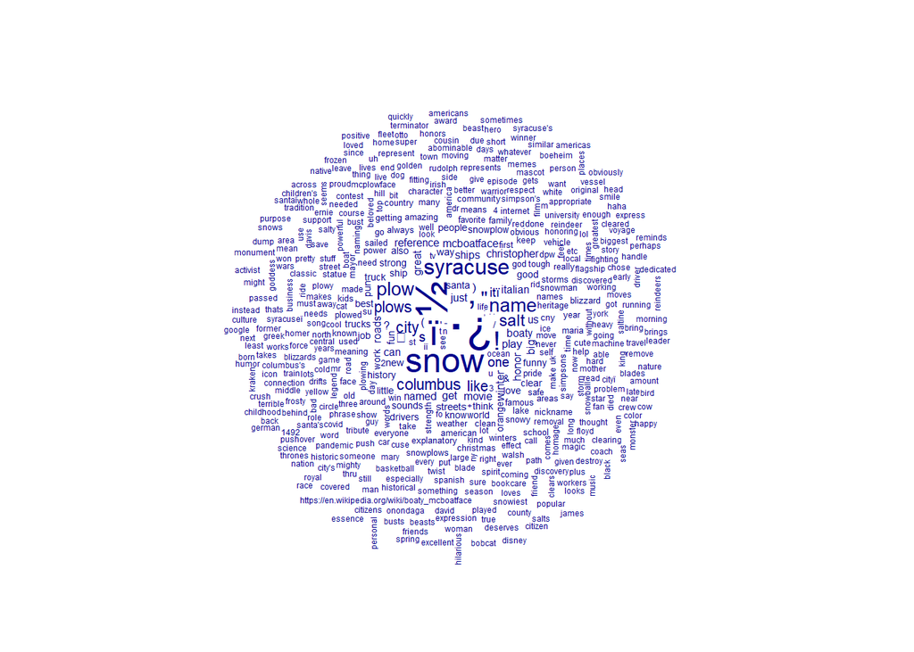

```r
textplot_wordcloud(dfm_meaning, min_count = 2)
```

5. Next, **increase the minimum count to 10**. What happens to the word cloud? **Explain in a comment**.

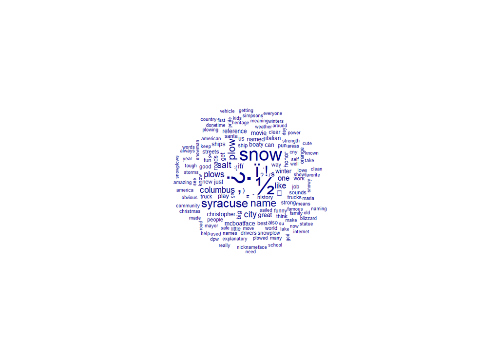

```r
textplot_wordcloud(dfm_meaning, min_count = 10)
```

```r
#As we would expect, the word cloud has many less words within it and is much smaller because the count is substantially higher
```

6. What are the top words in the word cloud? Explain in a brief comment.

```r
#The tops words seem to be words like snow, plow, Syracuse, and the upside down question mark and 1/2.
```

## Part 2: Analyze the sentiment of the descriptions

1. Create a **named list of word counts by frequency**.

output the 10 most frequent words (their word count and the word).

**Hint**: use **textstat_frequency()** from the *quanteda.textstats* package.

```r
library(quanteda.textstats)
word_freq <- textstat_frequency(dfm_meaning)
top_words <- word_freq %>%
  head(10) %>%
  select(feature, frequency)
named_list <- setNames(as.list(top_words$frequency), top_words$feature)
print(named_list)
```

```
## $.
## [1] 674
##
## $`¿`
## [1] 452
##
## $`½`
## [1] 432
##
## $ï
## [1] 336
##
## $snow
## [1] 321
##
## $`,`
## [1] 319
##
## $`!`
## [1] 215
##
## $syracuse
## [1] 174
##
## $name
## [1] 143
##
## $plow
## [1] 140
```

2. Explain in a comment what you observed in the sorted list of word counts.

```r
#We can see the top 10 words as well as the counts with them which shows the top 'word' was . and the second was the upside down question mark. All the way down to the 10th being the word plow with 140
```

## Part 3: Match the words with positive and negative words

1. Read in the list of positive words, using the scan() function, and output the first 5 words in the list. Do the same for the the negative words list:  
   https://intro-datascience.s3.us-east-2.amazonaws.com/positive-words.txt  
   https://intro-datascience.s3.us-east-2.amazonaws.com/negative-words.txt

There should be 2006 positive words and 4783 negative words, so you may need to clean up these lists a bit.

```r
positive_words_url <- "https://intro-datascience.s3.us-east-2.amazonaws.com/positive-words.txt"
negative_words_url <- "https://intro-datascience.s3.us-east-2.amazonaws.com/negative-words.txt"
positive_words <- scan(positive_words_url, what = "character", sep = "\n")
negative_words <- scan(negative_words_url, what = "character", sep = "\n")
head(positive_words, 5)
```

```
## [1] ";;;;;;;;;;;;;;;;;;;;;;;;;;;;;;;;;;;;;;;;;;;;;;;;;;;;;;;;;;;;;;;;;;;;;;;;;;;;"
## [2] "; "
## [3] "; Opinion Lexicon: Positive"
## [4] ";"
## [5] "; This file contains a list of POSITIVE opinion words (or sentiment words)."
```

```r
head(negative_words, 5)
```

```
## [1] ";;;;;;;;;;;;;;;;;;;;;;;;;;;;;;;;;;;;;;;;;;;;;;;;;;;;;;;;;;;;;;;;;;;;;;;;;;;;;;"
## [2] "; "
## [3] "; Opinion Lexicon: Negative"
## [4] ";"
## [5] "; This file contains a list of NEGATIVE opinion words (or sentiment words)."
```

2. Use **dfm_match()** to match the words in the dfm with the words in posWords). Note that **dfm_match()** creates a new dfm.

Then pass this new dfm to the **textstat_frequency()** function to see the positive words in our corpus, and how many times each word was mentioned.

```r
dfm_positive <- dfm_match(dfm_meaning, features = positive_words)
positive_word_freq <- textstat_frequency(dfm_positive)
print(positive_word_freq)
```

```
##             feature frequency rank docfreq group
## 1              like        88    1      85   all
## 2             honor        47    2      47   all
## 3             great        43    3      43   all
## 4              good        28    4      28   all
## 5               fun        27    5      24   all
## 6            strong        25    6      25   all
## 7              best        23    7      22   all
## 8              love        21    8      21   all
## 9              work        21    8      21   all
## 10            clear        19   10      19   all
## 11           famous        16   11      16   all
## 12            pride        16   11      16   all
## 13             safe        16   11      16   all
## 14            tough        15   14      15   all
```

[output cut: 205 more lines]

C. Sum all the positive words

```r
total_positive_words <- sum(colSums(dfm_positive))
print(total_positive_words)
```

```
## [1] 930
```

D. Do a similar analysis for the negative words - show the 10 most requent negative words and then sum the negative words in the document.

```r
dfm_negative <- dfm_match(dfm_meaning, features = negative_words)
negative_word_freq <- textstat_frequency(dfm_negative)
head(negative_word_freq,10)
```

```
##    feature frequency rank docfreq group
## 1    funny        25    1      25   all
## 2        ;         8    2       8   all
## 3        ;         8    2       8   all
## 4        ;         8    2       8   all
## 5        ;         8    2       8   all
## 6        ;         8    2       8   all
## 7        ;         8    2       8   all
## 8        ;         8    2       8   all
## 9        ;         8    2       8   all
## 10    cold         8    2       8   all
```

```r
total_negative_words <- sum(colSums(dfm_negative))
print(total_negative_words)
```

```
## [1] 319
```

5. Write a comment describing what you found after matching positive and negative words. Which group is more common in this dataset? Might some of the negative words not actually be used in a negative way? What about the positive words?

```r
#Positive words were used much more often than negative words, and I believe both positive and negative words were likely misused or misinterpreted because it is such a subjective and case by case matter
```